# Creating custom import functions

The first thing we need to do is to create a function that will read this data in a format that can be used by `eemR`. **The function needs to meet these flowing criteria:**

1. Have an argument `file` that will contains the path of the file(s) to read.
2. Return a list containing the flowing elements:
   - `file`: the path of the file
   - `em`: a numeric vector containing emission wavelengths.
   - `ex`: a numeric vector containing excitation wavelengths.
   - `x`: a matrix of `length(em)` rows by `length(ex)` columns.

Further more, the `x` matrix of the list need to be arranged as follow:

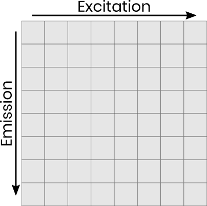

Let’s now write a function that will read the eem file and format the data accordingly. In this particular example, fluorescence has been measured in asynchronous mode. Hence, extra manipulations are needed to get the data on a regular grid.

```r
library(dplyr)
library(tidyr)
library(eemR)

import_cary <- function(file) {
  dat <- read.csv(file, nrows = 102, skip = 1)

  ex <- na.omit(dat[, 1])
  em <- seq(50, 330, by = 5)

  em <- outer(ex, em, "+")
  em <- as.vector(em)
  ex <- rep(ex, 57)

  x <- dat[, -1]
  x <- x[-1, ]
  x <- matrix(as.numeric(unlist(x, use.names = FALSE)), ncol = 101, byrow = FALSE)

  res <- tibble(ex, em, x = as.vector(x)) %>%
    arrange(ex, em) %>%
    complete(ex, em, fill = list(x = NA))

  ex <- sort(unique(ex))
  em <- sort(unique(em))
  x <- matrix(res$x, ncol = length(ex), byrow = TRUE)

  # We need to interpolate because you do not have a regular grid (i.e. asynchronous)
  r <- MBA::mba.surf(res %>% drop_na(), no.X = 200, no.Y = 200, extend = FALSE)

  l <- list(
    file = file,
    x = t(r$xyz.est$z),
    ex = r$xyz.est$x,
    em = r$xyz.est$y
  )

  return(l)
}
```

We can now try our function and have a look to the structure of the returned list.

```r
str(import_cary(file))
```

```
#> List of 4
#>  $ file: chr "/tmp/RtmpSTexCY/Rinst2df4b21a9c058/eemR/extdata/custom_cary.csv"
#>  $ x   : num [1:200, 1:200] 1.91 2.29 2.73 3.04 3.27 ...
#>  $ ex  : num [1:200] 250 251 252 253 254 ...
#>  $ em  : num [1:200] 300 302 305 307 310 ...
```

We will use the `import_function` argument of the `eem_read()` function to tell `eemR` how to read our file.

```r
eem <- eem_read(file, import_function = import_cary)

eem
```

```
#>        sample ex_min ex_max em_min em_max is_blank_corrected
#> 1 custom_cary    250    450    300    780              FALSE
#>   is_scatter_corrected is_ife_corrected is_raman_normalized
#> 1                FALSE            FALSE               FALSE
```

We can visualize the eem by using the `plot()` function:

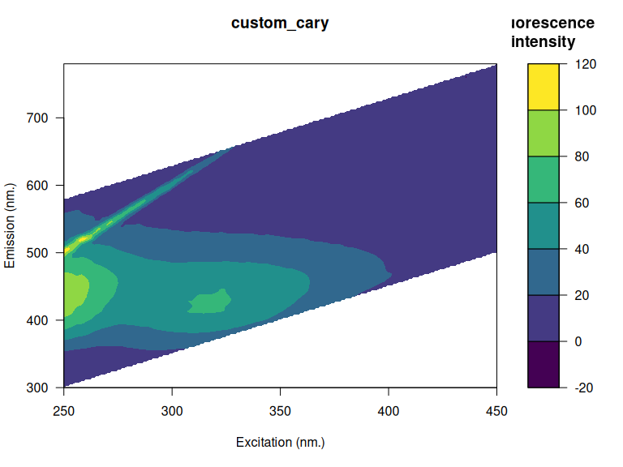

```r
plot(eem)
```

All other functions of the `eemR` package can now be used on the created `eem`. For example, we can remove the second order scattering.

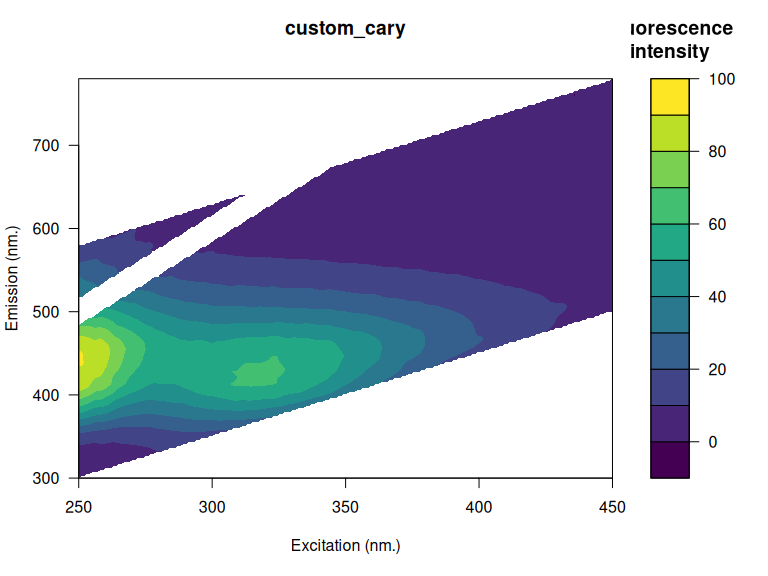

```r
# Remove second order Rayleigh scattering
plot(eem_remove_scattering(eem, "rayleigh", order = 2, width = 15))
```

```r
# Extract Coble' peaks
eem_coble_peaks(eem)
```

[output not shown]